# Actuarial 3 Tarea 1

Actuarial 3

Autor/a

Marcelino Sánchez

Fecha de publicación

26 de agosto de 2023

# Ejercicio 1

2. ¿Cuál es la prima recargada individual que se debe cobrar a cada asegurado si se considera un margen de seguridad de 0.5? ¿Cómo se compara frente a la respectiva prima neta individual? [10]

```r
mediaDistPerd <- 80

varDistPerd <- 80^2

# Averiguando valor de lambda

funcionLambda <- function(lambda){
  return((1+lambda)*exp(-lambda)-1+.0265)
}

# Encontrar la raíz usando uniroot
resultado <- uniroot(funcionLambda, interval = c(0, 1))

# Imprimir el resultado
cat("El valor de lambda que hace que la función sea aproximadamente cero es:", resultado$root, "\n")
```

```
El valor de lambda que hace que la función sea aproximadamente cero es: 0.2500015
```

```r
#Prima recargada

mediaDistFrec <- 48*resultado$root

vardDistFrec <- 48*resultado$root

esperanzaS <- mediaDistPerd*mediaDistFrec

varianzaS <- varDistPerd*mediaDistFrec + vardDistFrec*mediaDistPerd^2

paramRecargada <- 0.5

primaRecargada <- 1000*(esperanzaS+paramRecargada*sqrt(varianzaS))/48

cat("La prima recargada agregada es:",primaRecargada , "\n")
```

[output not shown]

```r
cat("La prima recargada individual es:", (primaRecargada/48)*1000, "\n")
```

[output not shown]

```r
primaNetaIndividual <-  (esperanzaS/48)*1000

cat("La prima neta individual es:", primaNetaIndividual, "\n")
```

```
La prima neta individual es: 20000.12
```

```r
cat("Con lo cual la recargada es ",primaRecargada/primaNetaIndividual, " veces la neta", "\n" )
```

```
Con lo cual la recargada es  1.204124  veces la neta
```

3. Aproxime la distribución de S mediante el Teorema Central del Límite para encontrar el margen de seguridad que garantice con 99.5% de probabilidad que la prima recargada agregada será suficiente para hacer frente a las obligaciones de este seguro. ¿Cuál sería la prima recargada individual en este caso? [10]

```r
# Aproximación de la distribución de S mediante el TCL

# Ya tenemos la media y varianza de S

# Calculamos la alfa que nos da el 99.5% de seguridad

alfa <- qnorm(0.995)

# Calculamos la prima recargada

(primaRecargada <- (esperanzaS+alfa*sqrt(varianzaS))*1000)
```

```
[1] 1969524
```

```r
(primaRecargadaInd <- (primaRecargada/48))
```

```
[1] 41031.74
```

# Ejercicio 2

```r
# Cargamos librerías

library(readxl)
library(openxlsx)
library(lubridate)
library(dplyr)  # Load the dplyr package for data manipulation
library(ggplot2)
library(tidyr)
```

```r
# Set the path to the Excel file and the sheet name

file_path <- paste0(getwd(), "/bases/Tarea1.xlsx")
sheet_name <- "2"

# Read the entire sheet into a data frame
sheet <- read_excel(file_path, sheet = sheet_name, range = "A7:D427")

# Extract year and month from the Fecha column
sheet$Month <- lubridate::month(sheet$Fecha)
sheet$Year <- lubridate::year(sheet$Fecha)
sheet$Day <- lubridate::day(sheet$Fecha)

sheet$Year <- as.factor(sheet$Year)
sheet$Month <- as.factor(sheet$Month)
sheet$Ramo <- as.factor(sheet$Ramo)

# Print the table
head(sheet)
```

```
# A tibble: 6 × 7
  Fecha                 Año Ramo                 Monto Month Year    Day
  <dttm>              <dbl> <fct>                <dbl> <fct> <fct> <int>
1 2020-01-02 00:00:00  2020 Incendio y propiedad  2.91 1     2020      2
2 2020-01-02 00:00:00  2020 Marítimo              1.23 1     2020      2
3 2020-01-05 00:00:00  2020 Marítimo              7.26 1     2020      5
4 2020-01-06 00:00:00  2020 Incendio y propiedad  7.70 1     2020      6
5 2020-01-09 00:00:00  2020 Incendio y propiedad  1.93 1     2020      9
6 2020-01-12 00:00:00  2020 Incendio y propiedad  1.43 1     2020     12
```

```r
summary(sheet)
```

```
     Fecha                             Año                          Ramo
 Min.   :2020-01-02 00:00:00.00   Min.   :2020   Catastrofico         : 12
 1st Qu.:2020-12-12 06:00:00.00   1st Qu.:2020   Incendio y propiedad :228
 Median :2021-10-05 00:00:00.00   Median :2021   Marítimo             :120
 Mean   :2021-09-06 14:41:08.56   Mean   :2021   Responsabilidad civil: 60
 3rd Qu.:2022-06-08 06:00:00.00   3rd Qu.:2022
 Max.   :2022-12-31 00:00:00.00   Max.   :2022

     Monto            Month       Year          Day
 Min.   : 0.113   5      : 43   2020:110   Min.   : 1.00
 1st Qu.: 2.571   9      : 41   2021:130   1st Qu.: 7.00
 Median : 4.463   7      : 39   2022:180   Median :15.00
 Mean   : 6.733   3      : 38              Mean   :15.01
 3rd Qu.: 7.201   10     : 38              3rd Qu.:22.00
 Max.   :77.042   12     : 38              Max.   :31.00
                  (Other):183
```

2. Construya una gráfica que permita analizar la evolución mensual del número de reclamaciones por ramo de 2020 a 2022

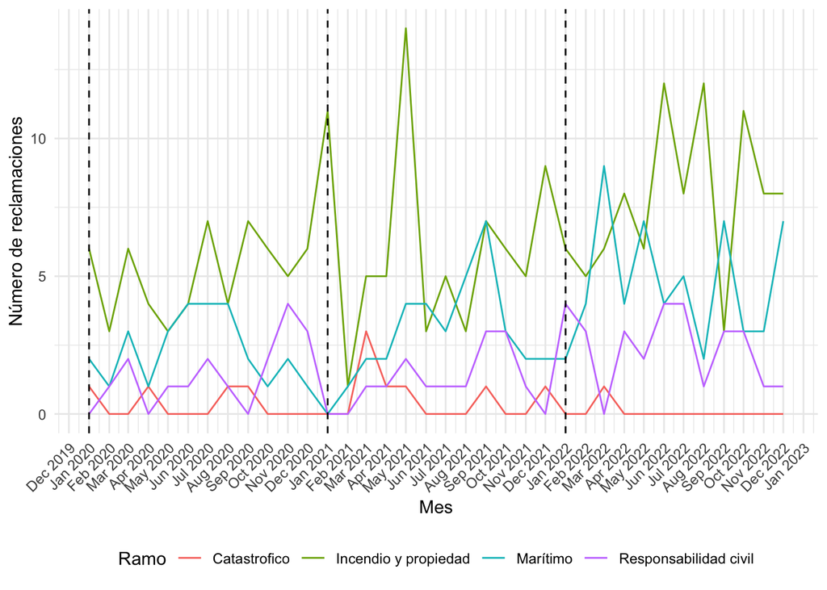

```r
# Create a grid of all possible Year, Month, and Ramo combinations
all_combinations <- expand.grid(Year = unique(sheet$Year),
                                Month = unique(sheet$Month),
                                Ramo = unique(sheet$Ramo)) %>%
                                arrange(Year, Month, Ramo)

# Agrupamos los datos por año, mes y ramo

agg_data <- sheet %>%
  group_by(Year, Month, Ramo) %>%
  summarise(Num_Reclamaciones = n())
# Left join the grid with your data
grouped_data <- all_combinations %>%
  left_join(agg_data, by = c("Year", "Month", "Ramo")) %>%
  mutate(Num_Reclamaciones = ifelse(is.na(Num_Reclamaciones), 0, Num_Reclamaciones))

# Create the plot with faceting by year and connected lines across months
ggplot(grouped_data, aes(x = as.Date(paste(Year, Month, "01", sep = "-")), y = Num_Reclamaciones, color = Ramo, group = Ramo)) +
  geom_line() +
  geom_vline(aes(xintercept = as.Date(paste(Year, "01-01", sep = "-"))), color = "black", linetype = "dashed") +
  labs(x = "Mes", y = "Número de reclamaciones", color = "Ramo") +
  scale_x_date(date_labels = "%b %Y", date_breaks = "1 month") +
  theme_minimal() +
  theme(legend.position = "bottom") +
  theme(axis.text.x = element_text(angle = 45, hjust = 1))  # Rotate x-axis labels for readability
```

3. Con la información de los 3 años construya 4 histogramas de los montos individuales de los siniestros de cada uno de los ramos. [10]

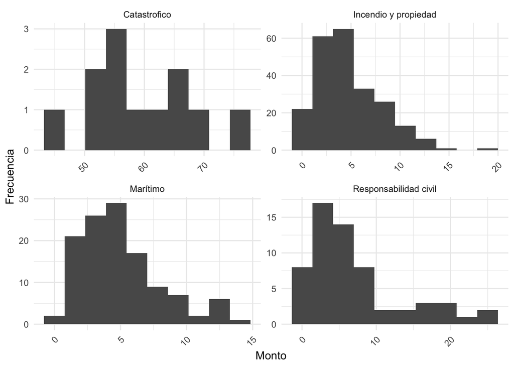

```r
# Cargar el paquete necesario
library(ggplot2)

# Crear los histogramas

ggplot(sheet, aes(x = Monto)) +
  geom_histogram(bins = 10) +
  facet_wrap(~ Ramo, scales = "free" ) +
  labs(x = "Monto", y = "Frecuencia") +
  theme_minimal() +
  theme(legend.position = "bottom") +
  theme(axis.text.x = element_text(angle = 45, hjust = 1))  # Rotate x-axis labels for readability
```

4. Se quiere analizar exclusivamente el ramo Catastrófico de 2020 a 2022:
5. Grafique el proceso de siniestros agregados. [10]

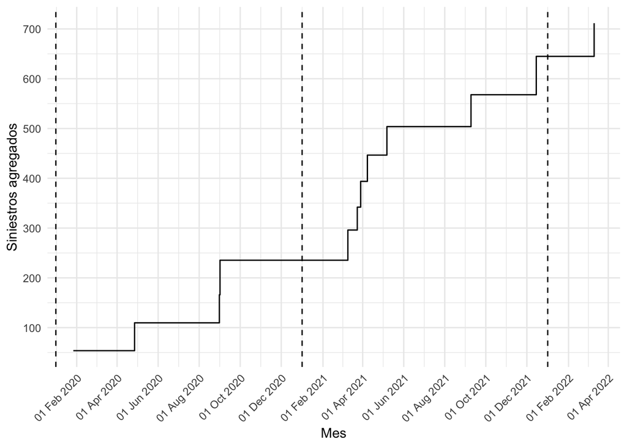

```r
catSheet <- sheet %>%
  filter(Ramo == "Catastrofico") %>%
  mutate(acumMonto = cumsum(Monto))

ggplot(catSheet, aes(x = as.Date(paste(Year, Month, Day,
sep = "-")), y = acumMonto)) + geom_step() +
  geom_vline(aes(xintercept = as.Date(paste(Year, "01-01", sep = "-"))), color = "black", linetype = "dashed") +
  labs(x = "Mes", y = "Siniestros agregados", color = "Ramo") +
  scale_x_date(date_labels = "%d %b %Y", date_breaks = "2 month") +
  scale_y_continuous(breaks = seq(0,800, 100) ) +
  theme_minimal() +
  theme(legend.position = "bottom") +
  theme(axis.text.x = element_text(angle = 45, hjust = 1))  # Rotate x-axis labels for readability
```

2. Suponga que la aseguradora cobró como prima neta agregada el monto total de los 12 siniestros y que cobró una tercera parte al inicio de cada año a sus asegurados. Grafique el proceso de primas recolectadas. [5]

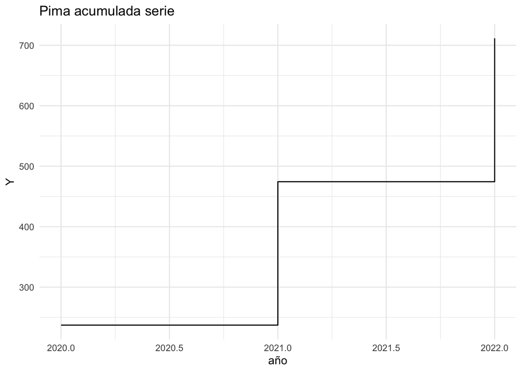

```r
prima_agregada_final <- tail(catSheet$acumMonto, 1)

prima_agregada_func <- function(x){
  return(x*prima_agregada_final/3)
}

x_values <- seq(2020, 2022,1)
y_values <- sapply(x_values+1-2020, prima_agregada_func)

# Create an igraph graph
prima_agregada_serie <-data.frame(x_values = x_values, y_values = y_values)

# Plot the graph using ggplot2
ggplot(prima_agregada_serie, aes(x = x_values, y = y_values)) +
  geom_step() +
  scale_y_continuous(breaks = seq(0,800, 100) ) +
  labs(x = "año", y = "Y", title = "Pima acumulada serie") +
  theme_minimal()
```

3. Si la Aseguradora tenía un capital inicial para estos riesgos de 50 millones de dólares, combine los procesos anteriores para graficar el proceso de excedentes. ¿Qué puede concluir? (Sugerencia: Considere el tiempo en el que se presenta el primer excedente por debajo del capital inicial y el tiempo de ruina). [10]

```r
# Crear un data frame con los datos de los excedentes

serieMontos <- catSheet %>%
  select(Year, Month, Day, Monto)

for (i in 1:3) {
  new_row <- c(as.character(2020 + i-1), "1", "1", -prima_agregada_func(1))
  serieMontos <- rbind(serieMontos, new_row)
}

serieMontos <- serieMontos %>%
  arrange(Year, Month, Day) %>%
  mutate(excedente = 50-cumsum(Monto))

# Filtrar rows donde el excedente es negativo y
#donde el excedente es menor a 50

serieMontos <- serieMontos %>%
  mutate(excedenteMenor50 = excedente < 50,
         excedenteNegativo = excedente < 0)
print(serieMontos[serieMontos$excedenteNegativo,])
```

```
# A tibble: 2 × 7
  Year  Month Day   Monto  excedente excedenteMenor50 excedenteNegativo
  <fct> <fct> <chr> <chr>      <dbl> <lgl>            <lgl>
1 2021  9     9     64.071     -43.5 TRUE             TRUE
2 2021  12    15    77.042    -121.  TRUE             TRUE
```

```r
print(serieMontos[serieMontos$excedenteMenor50,])
```

```
# A tibble: 4 × 7
  Year  Month Day   Monto  excedente excedenteMenor50 excedenteNegativo
  <fct> <fct> <chr> <chr>      <dbl> <lgl>            <lgl>
1 2021  5     7     57.22       20.6 TRUE             FALSE
2 2021  9     9     64.071     -43.5 TRUE             TRUE
3 2021  12    15    77.042    -121.  TRUE             TRUE
4 2022  3     11    66.663      50.0 TRUE             FALSE
```

[figure not shown]

```r
# Extract points where excedenteNegativo is TRUE
points_excedente_negativo <- head(serieMontos[serieMontos$excedenteNegativo,],1)

# Extract points where excedenteMenor50 is TRUE
points_excedente_menor_50 <- head(serieMontos[serieMontos$excedenteMenor50,],1)

# Graficar el proceso de excedentes
ggplot(serieMontos, aes(x = as.Date(paste(Year, Month, Day,
sep = "-")), y = excedente)) + geom_step() +
  geom_vline(aes(xintercept = as.Date(paste(Year, "01-01", sep = "-"))), color = "black", linetype = "dashed") +
  labs(x = "Mes y año", y = "Excedente") +
  scale_x_date(date_labels = "%d %b %Y", date_breaks = "1 month") +
  geom_hline(yintercept = 0, color = "red") +
  geom_hline(yintercept = 50, color = "blue") +
  theme_minimal() +
  theme(legend.position = "bottom") +
  theme(axis.text.x = element_text(angle = 45, hjust = 1))+ # Rotate x-axis labels for readability
  geom_point(data = points_excedente_negativo, aes(x = as.Date(paste(Year, Month, Day, sep = "-")), y = excedente), color = "red") +
  geom_point(data = points_excedente_menor_50, aes(x = as.Date(paste(Year, Month, Day, sep = "-")), y = excedente), color = "blue")+
  geom_text(data = points_excedente_negativo, aes(label = as.Date(paste(Day, Month, Year, sep = "-")), x = as.Date(paste(Year, Month, Day, sep = "-")), y = excedente), vjust = 1.5, color = "red") +
  geom_text(data = points_excedente_menor_50, aes(label = as.Date(paste(Day, Month, Year, sep = "-")), x = as.Date(paste(Year, Month, Day, sep = "-")), y = excedente), vjust = 1.5, color = "blue")
```

# Ejercicio 4

Situación Financiera de las Aseguradoras.

En el archivo “Tarea 1.xls” aparecen Estados Financieros de las 83 Compañías Aseguradoras en México al 31 de diciembre de 2022. Considere la muestra integrada por las 25 principales Compañías Aseguradoras en términos de prima emitida para responder lo siguiente.

```r
# Set the path to the Excel file and the sheet name

file_path <- paste0(getwd(), "/bases/Tarea1.xlsx")
sheet_name <- "4"

# Read the entire sheet into a data frame
sheet2 <- read_excel(file_path, sheet = sheet_name, range = "A8:AP91")

names(sheet2)
```

```
 [1] "Aseguradora"
 [2] "Inversiones"
 [3] "Inversiones para Obligaciones Laborales"
 [4] "Disponibilidad"
 [5] "Deudores"
 [6] "Reaseguradores y Reafianzadores (Activo)"
 [7] "Inversiones Permanentes"
 [8] "Otros Activos"
 [9] "Activo Total"
[10] "Reserva de Riesgos en Curso"
[11] "Reserva para Obligaciones Pendientes de Cumplir"
[12] "Reserva de Contingencia"
[13] "Reservas de Riesgos Catastróficos"
[14] "Total Reservas Técnicas"
[15] "Reservas para Obligaciones Laborales"
```

[output cut: 27 more lines]

```r
summary(sheet2)
```

```
 Aseguradora         Inversiones        Inversiones para Obligaciones Laborales
 Length:83          Min.   :    10.87   Min.   :   0.000
 Class :character   1st Qu.:   290.53   1st Qu.:   0.000
 Mode  :character   Median :  1566.21   Median :   1.309
                    Mean   : 13696.99   Mean   :  82.221
                    3rd Qu.:  5638.68   3rd Qu.:  51.324
                    Max.   :159860.55   Max.   :1394.626
 Disponibilidad         Deudores
 Min.   :   0.3194   Min.   :    0.003
 1st Qu.:   8.7440   1st Qu.:   94.008
 Median :  33.0219   Median :  457.430
 Mean   : 170.3006   Mean   : 2352.324
 3rd Qu.:  99.1126   3rd Qu.: 1450.221
 Max.   :1894.8787   Max.   :30877.920
 Reaseguradores y Reafianzadores (Activo) Inversiones Permanentes
 Min.   :    0.00                         Min.   :    0.00
 1st Qu.:   80.02                         1st Qu.:    0.00
 Median :  421.59                         Median :    0.37
 Mean   : 1401.86                         Mean   :  406.30
 3rd Qu.: 1187.08                         3rd Qu.:   33.86
 Max.   :11844.03                         Max.   :15364.07
 Otros Activos      Activo Total       Reserva de Riesgos en Curso
 Min.   : -45.51   Min.   :    38.73   Min.   :     0.0
 1st Qu.:  33.25   1st Qu.:  1067.09   1st Qu.:   175.6
 Median : 128.67   Median :  3321.77   Median :   859.9
 Mean   : 743.99   Mean   : 18853.99   Mean   : 10981.2
 3rd Qu.: 613.78   3rd Qu.: 11081.88   3rd Qu.:  2944.6
 Max.   :7392.24   Max.   :198098.25   Max.   :145819.0
 Reserva para Obligaciones Pendientes de Cumplir Reserva de Contingencia
 Min.   :    0.00                                Min.   :   0.00
 1st Qu.:   31.89                                1st Qu.:   0.00
 Median :  343.99                                Median :   0.00
 Mean   : 2305.57                                Mean   :  58.33
 3rd Qu.: 1751.38                                3rd Qu.:   0.00
 Max.   :19719.72                                Max.   :1014.26
 Reservas de Riesgos Catastróficos Total Reservas Técnicas
 Min.   :   0.000                  Min.   :     0.0
 1st Qu.:   0.000                  1st Qu.:   261.9
 Median :   0.002                  Median :  1598.3
 Mean   : 603.957                  Mean   : 13949.1
```

[output cut: 106 more lines]

```
 Max.   :12906.05
 Provisión para el Pago de Impuestos a la Utilidad
 Min.   :-860.24
 1st Qu.:   0.00
 Median :  26.47
 Mean   : 244.50
 3rd Qu.: 178.63
 Max.   :3121.18
 Utilidad  (Pérdida) del Ejercicio
 Min.   :-1263.037
 1st Qu.:    5.159
 Median :   63.360
 Mean   :  623.609
 3rd Qu.:  360.433
 Max.   : 9784.875
```

```r
muestrasEmpresas <- head(sheet2[order(sheet2$"Primas Emitidas", decreasing = T),],25)
```

CC a) Construya el histograma y el diagrama de caja y brazos para las inversiones como porcentaje del activo total. Interprete sus resultados en términos de la estructura financiera de las aseguradoras. [5]

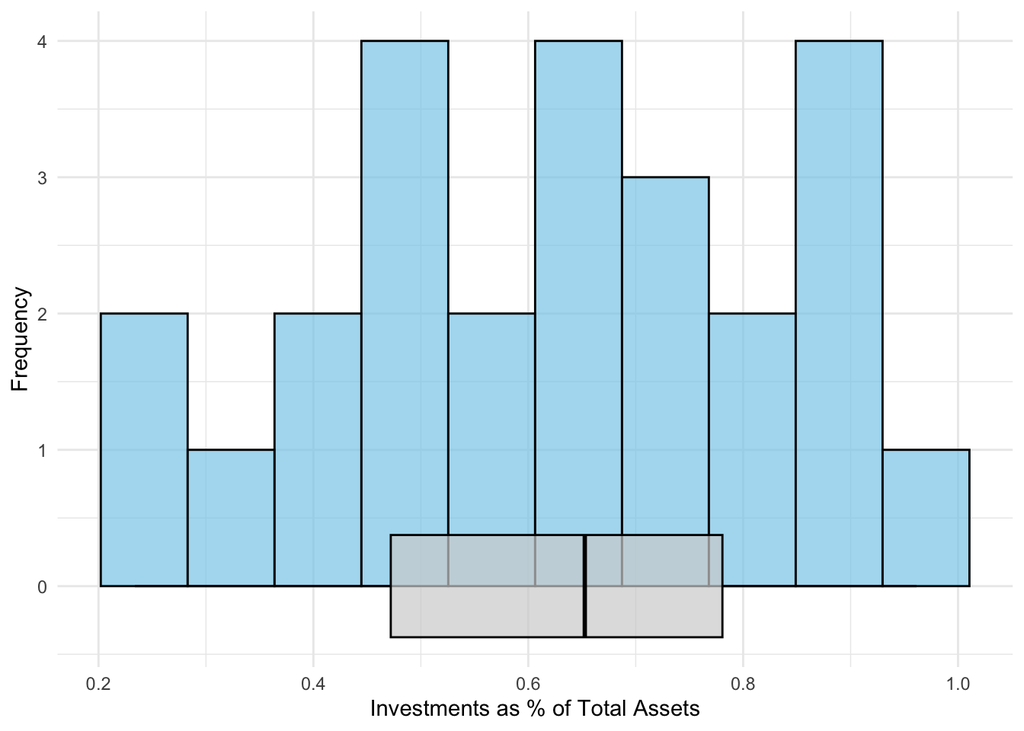

```r
muestrasEmpresas$percentage_column <- muestrasEmpresas$Inversiones/muestrasEmpresas$"Activo Total"

ggplot(muestrasEmpresas, aes(x = percentage_column)) +
  geom_histogram(bins= 10, fill = "skyblue", color = "black", alpha = 0.7) +
  geom_boxplot( fill = "lightgray", color = "black", alpha = 0.7,outlier.colour = "red") +
  labs(x = "Investments as % of Total Assets", y = "Frequency") +
  theme_minimal()
```

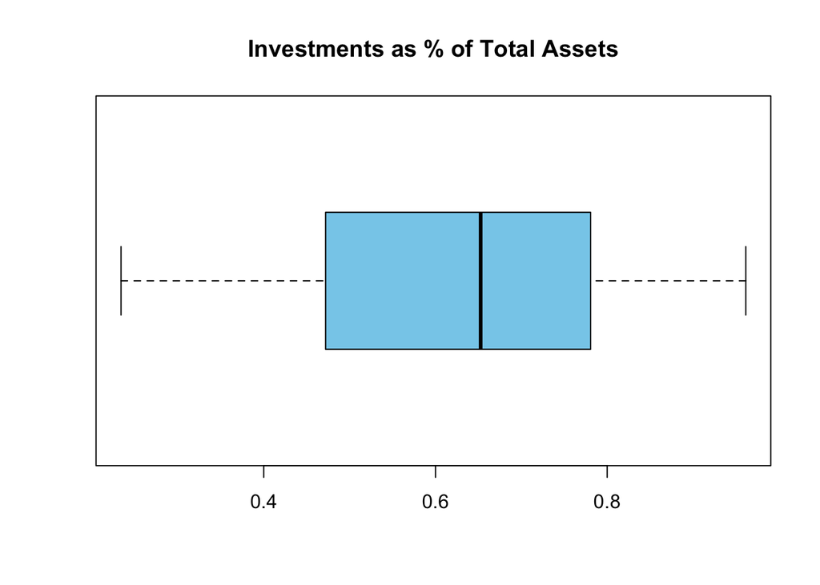

```r
boxplot(muestrasEmpresas$percentage_column, main = "Investments as % of Total Assets", col = "skyblue", horizontal = TRUE)
```

CC b) Construya el histograma y el diagrama de caja y brazos para las reservas técnicas como porcentaje del pasivo total. Interprete sus resultados en términos de la estructura financiera de las aseguradoras. [5]

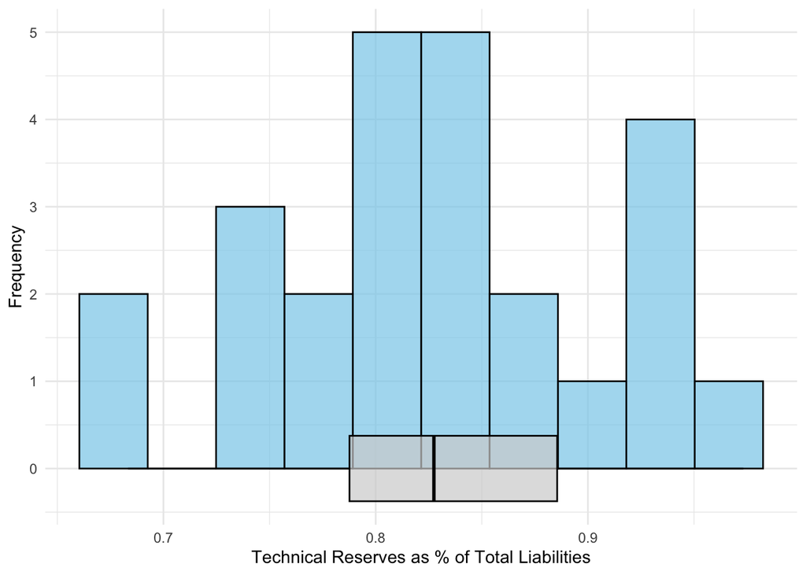

```r
muestrasEmpresas$percentage_column2 <- muestrasEmpresas$"Total Reservas Técnicas"/muestrasEmpresas$"Pasivo Total"

ggplot(muestrasEmpresas, aes(x = percentage_column2)) +
  geom_histogram(bins= 10, fill = "skyblue", color = "black", alpha = 0.7) +
  geom_boxplot( fill = "lightgray", color = "black", alpha = 0.7,outlier.colour = "red") +
  labs(x = "Technical Reserves as % of Total Liabilities", y = "Frequency") +
  theme_minimal()
```

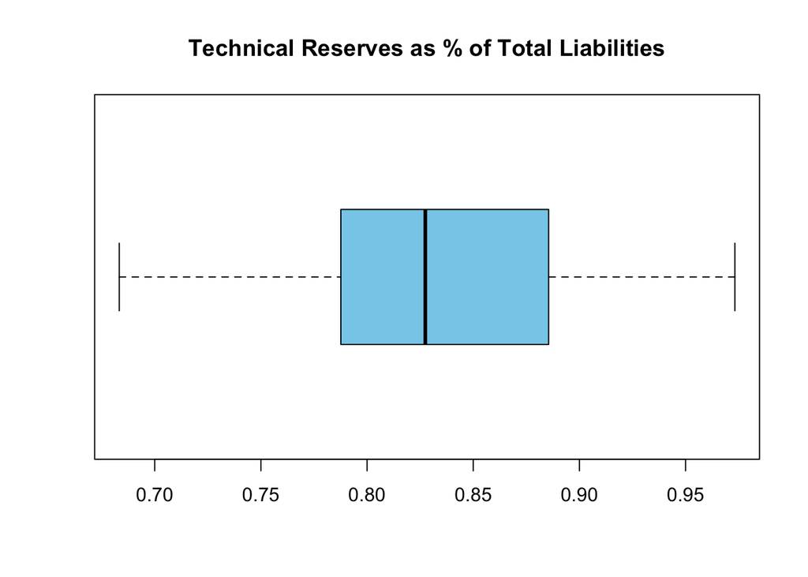

```r
boxplot(muestrasEmpresas$percentage_column2, main = "Technical Reserves as % of Total Liabilities", col = "skyblue", horizontal = TRUE)
```

CC c) Obtenga una gráfica de barras apiladas que permita comparar el tamaño de las 4 reservas técnicas como porcentaje del pasivo total para las 25 principales aseguradoras. ¿Qué puede concluir? [10]

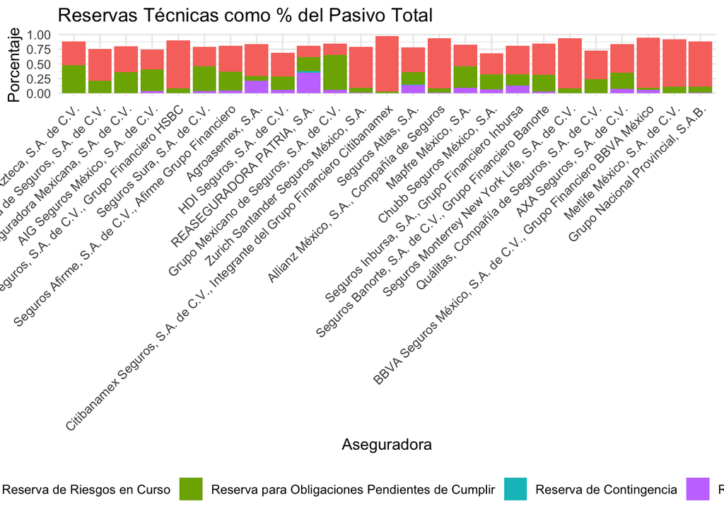

```r
muestrasEmpresasReservas <- muestrasEmpresas %>%
  select("Aseguradora", "Reserva de Riesgos en Curso", "Reserva para Obligaciones Pendientes de Cumplir", "Reserva de Contingencia", "Reservas de Riesgos Catastróficos","Total Reservas Técnicas", "Pasivo Total", "Primas Emitidas")

muestrasEmpresasReservas$percentage_column11 <- muestrasEmpresasReservas$"Reserva de Riesgos en Curso"/muestrasEmpresasReservas$"Pasivo Total"

muestrasEmpresasReservas$percentage_column12 <- muestrasEmpresasReservas$"Reserva para Obligaciones Pendientes de Cumplir"/muestrasEmpresasReservas$"Pasivo Total"

muestrasEmpresasReservas$percentage_column13 <- muestrasEmpresasReservas$"Reserva de Contingencia"/muestrasEmpresasReservas$"Pasivo Total"

muestrasEmpresasReservas$percentage_column14 <- muestrasEmpresasReservas$"Reservas de Riesgos Catastróficos"/muestrasEmpresasReservas$"Pasivo Total"

muestrasEmpresasReservas$percentage_column1 <- muestrasEmpresasReservas$"Total Reservas Técnicas"/muestrasEmpresasReservas$"Pasivo Total"

agrupamosReservas <- muestrasEmpresasReservas %>%
  select(
    Aseguradora,
    percentage_column11,
    percentage_column12,
    percentage_column13,
    percentage_column14,
    "Primas Emitidas"
  )

# Assuming you have aggregated data in the "agrupamosReservas" dataframe
# Reshape the data to a longer format

agrupamosReservas$Aseguradora <- factor(agrupamosReservas$Aseguradora,levels = agrupamosReservas$Aseguradora[order(agrupamosReservas$"Primas Emitidas")])

agrupamosReservas_long <- agrupamosReservas %>%
  pivot_longer(cols = starts_with("percentage_column"), names_to = "Reserva_Type", values_to = "Percentage")

# Create the stacked bar plot
ggplot(agrupamosReservas_long, aes(x = Aseguradora, y = Percentage, fill = Reserva_Type)) +
  geom_bar(stat = "identity") +
  labs(x = "Aseguradora", y = "Porcentaje") +
  ggtitle("Reservas Técnicas como % del Pasivo Total") +
  scale_fill_discrete(labels = c(
    "Reserva de Riesgos en Curso",
    "Reserva para Obligaciones Pendientes de Cumplir",
    "Reserva de Contingencia",
    "Reservas de Riesgos Catastróficos",
    "Total Reservas Técnicas"
  )) +
  theme_minimal() +
  theme(legend.position = "bottom") +
  theme(axis.text.x = element_text(angle = 45, hjust = 1))  # Rotate x-axis labels for readability
```

CC d) Analice mediante el diagrama de dispersión y el coeficiente de correlación lineal la relación entre: (i) el margen de utilidad (resultado del ejercicio / prima emitida) vs. la razón combinada;

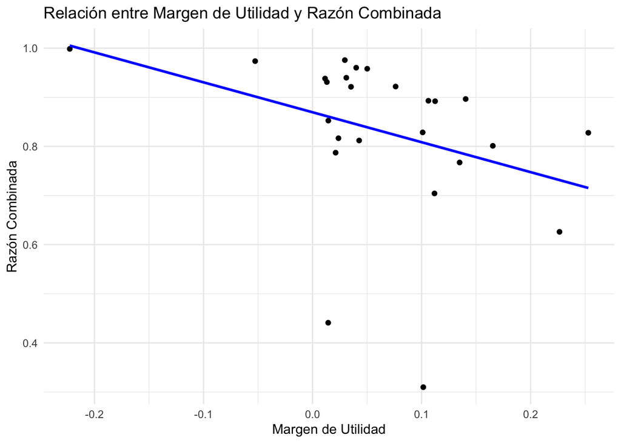

```r
muestrasEmpresas$margenUtilidad <- muestrasEmpresas$"Utilidad  (Pérdida) del Ejercicio"/muestrasEmpresas$"Primas Emitidas"
##CHECAR
muestrasEmpresas$razonCombinada <- (muestrasEmpresas$"Costo Neto de Siniestralidad, Reclamaciones y Otras Obligaciones Pendientes de Cumplir"+muestrasEmpresas$"Costo Neto de Adquisición")/(muestrasEmpresas$"Primas de Retención Devengadas")

# Create a scatter plot
ggplot(muestrasEmpresas, aes(x = margenUtilidad, y = razonCombinada)) +
  geom_point() +
  geom_smooth(method = "lm", se = FALSE, color = "blue") +
  labs(x = "Margen de Utilidad", y = "Razón Combinada") +
  ggtitle("Relación entre Margen de Utilidad y Razón Combinada") +
  theme_minimal()
```

```r
# Calculate the linear correlation coefficient
correlation <- cor(muestrasEmpresas$margenUtilidad, muestrasEmpresas$razonCombinada)
print(paste("Coeficiente de correlación lineal:", correlation))
```

```
[1] "Coeficiente de correlación lineal: -0.342509417544556"
```

y (ii) el margen de utilidad vs. el porcentaje de retención (prima de retención / prima emitida). ¿Qué pude concluir? [10]

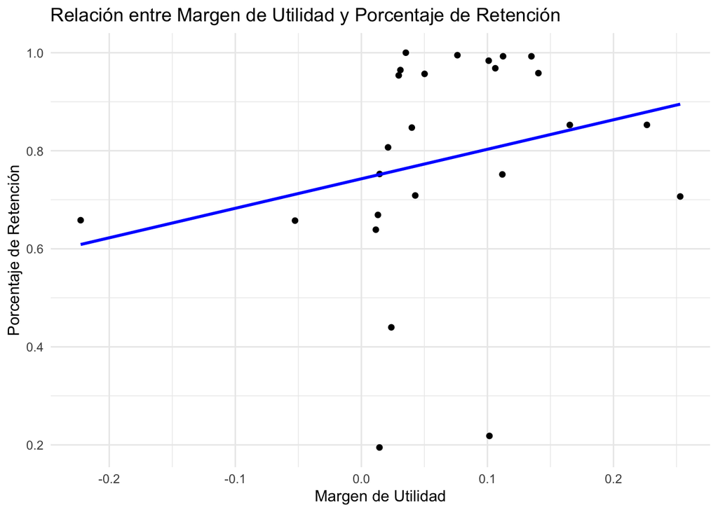

```r
muestrasEmpresas$porcentRetencion <- muestrasEmpresas$"Primas De Retención"/muestrasEmpresas$"Primas Emitidas"

# Create a scatter plot
ggplot(muestrasEmpresas, aes(x = margenUtilidad, y = porcentRetencion)) +
  geom_point() +
  geom_smooth(method = "lm", se = FALSE, color = "blue") +
  labs(x = "Margen de Utilidad", y = "Porcentaje de Retención") +
  ggtitle("Relación entre Margen de Utilidad y Porcentaje de Retención") +
  theme_minimal()
```

```r
# Calculate the linear correlation coefficient
correlation <- cor(muestrasEmpresas$margenUtilidad, muestrasEmpresas$porcentRetencion)
print(paste("Coeficiente de correlación lineal:", correlation))
```

```
[1] "Coeficiente de correlación lineal: 0.244267414864451"
```

No hay nada que se pueda decir, realmente no hay una correlación fuerte entre las variables